# BrainAge Cross Sectional Analysis

Jorge Garcia Condado

2025-11-26

# BrainAge modelling

A linear regression BrainAge model was trained for each cohort on e4 non-carriers and AB-. The model was then applied to the rest of the cohort.

The model was trained using the following features:

- Amygdala normalized volume
- Hippocampus normalized volume
- Inferior parietal cortical thickness
- Inferior temporal cortical thickness
- Middle temporal cortical thickness
- Entorhinal cortical thickness
- Parahippocampal cortical thickness
- Fusiform cortical thickness

# A4/LEARN

Command used: model_age -o analysis/final/a4 -f data/final/a4/processed/structural_features.csv –clinical data/final/a4/processed/clinical.csv

```
## Cognitively Unimpaired
```

```
## Delta mean: 0.1307302
```

```
## Delta std: 1.897531
```

## Delta differences

### E4 status

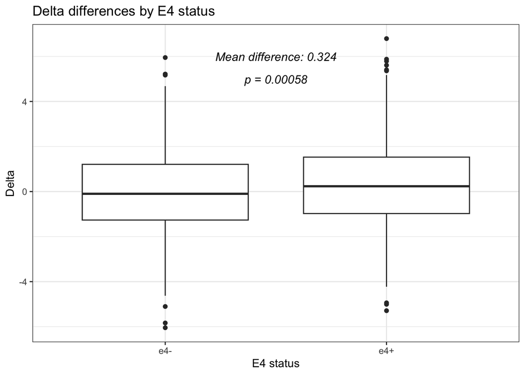

### Amyloid status

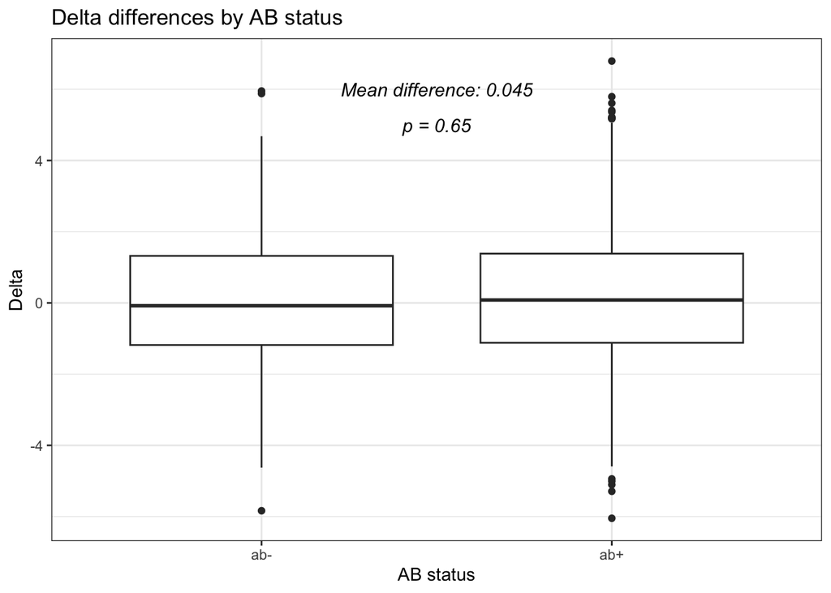

### Sex differences

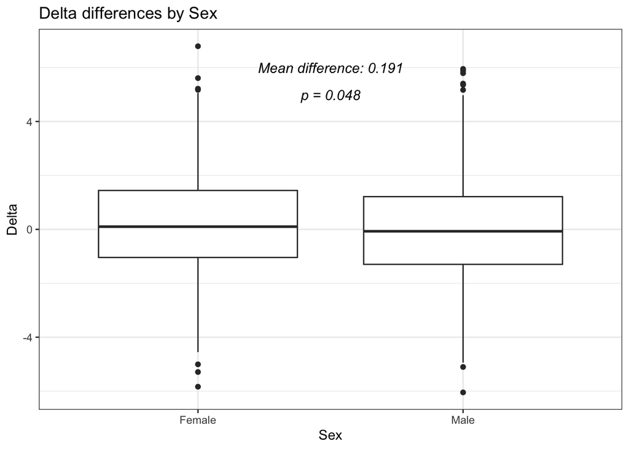

## Biomarkers

Correlation between BrainAge delt and different biomarkers. Sensitivity analysis includes addin sex, educaiton, APOEe4, AB-status and MRI Age as covariates. Further sensitivity analysis limits datapoints to those within 1 year of the MRI.

### PACC

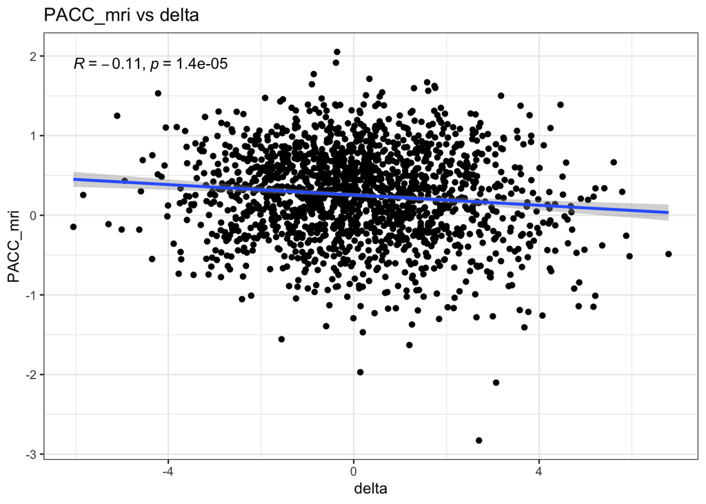

```
## Sensitivity analysis:
```

```
## Correlation with delta including covariates: -0.1096922 9.226859e-06
```

```
## Correlation with delta including covariates and time difference: -0.1096922 9.226859e-06
```

### AB

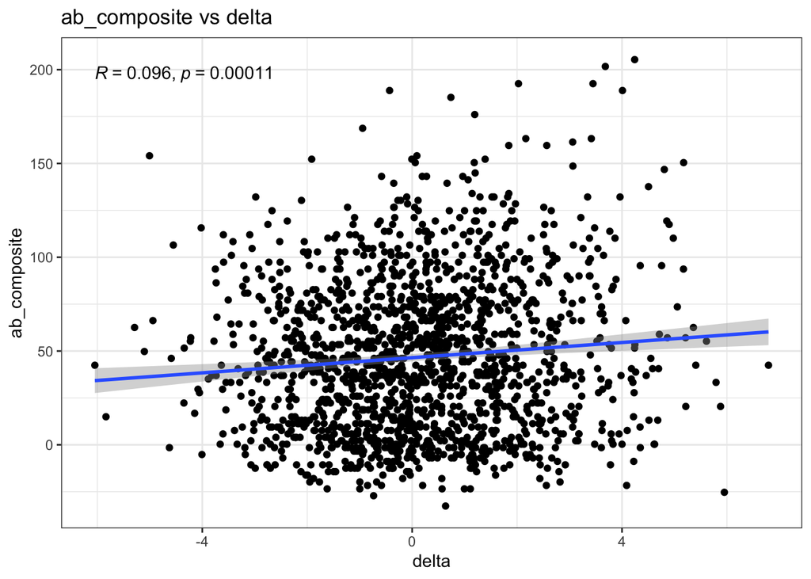

```
## Sensitivity analysis:
```

```
## Correlation with delta including covariates: 0.09647743 9.714027e-05
```

```
## Correlation with delta including covariates and time difference: 0.09677113 9.622892e-05
```

### ptau217

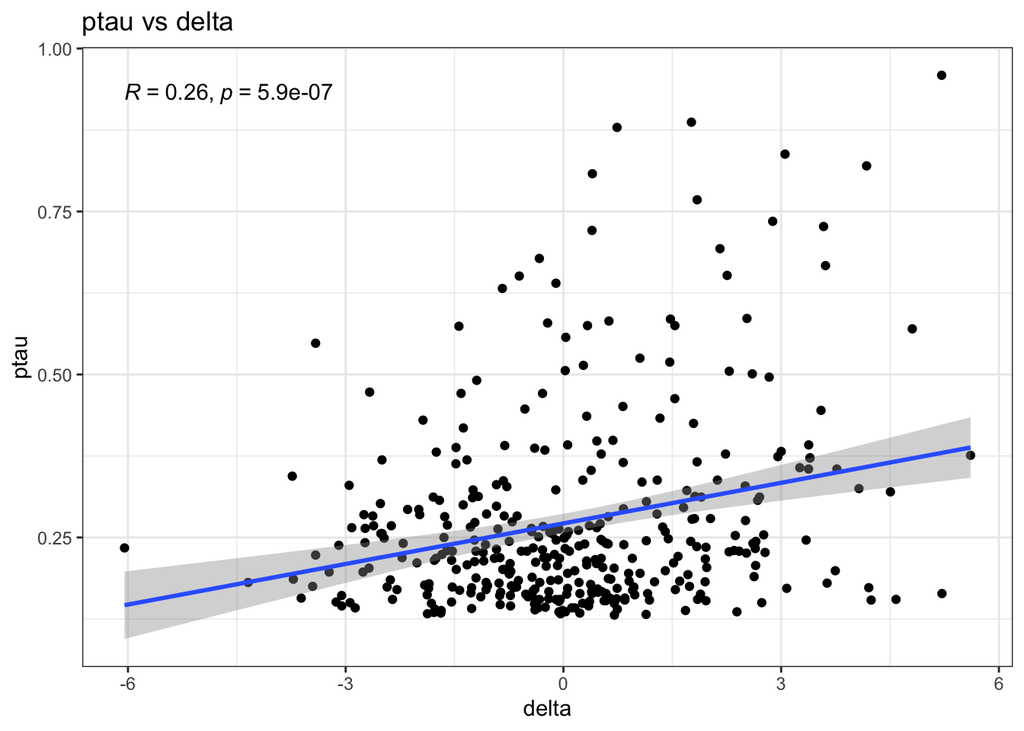

```
## Sensitivity analysis:
```

```
## Correlation with delta including covariates: 0.252764 1.358219e-06
```

```
## Correlation with delta including covariates and time difference: 0.2507583 1.895654e-06
```

### TAU

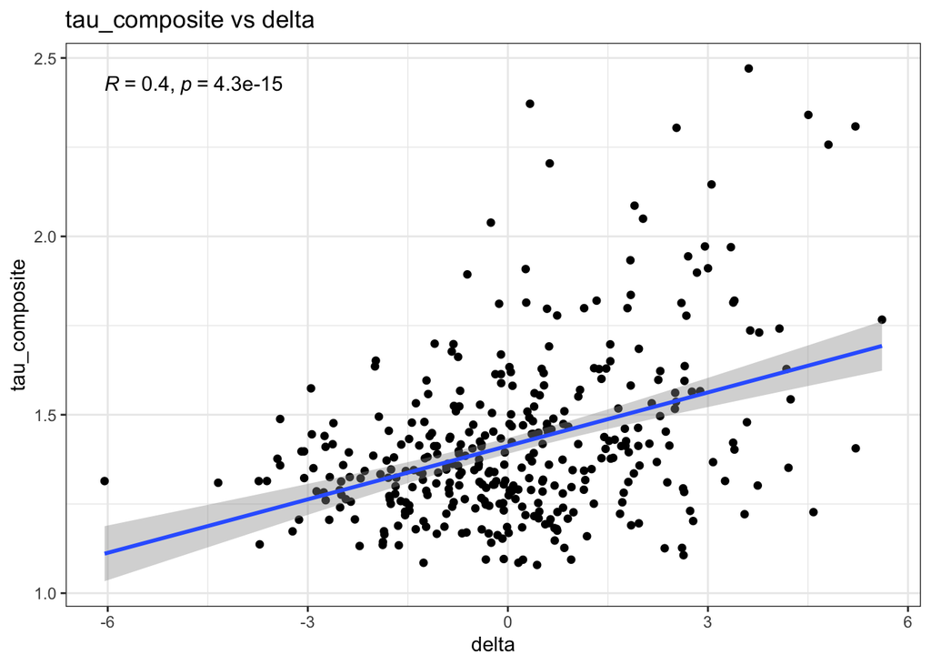

```
## Sensitivity analysis:
```

```
## Correlation with delta including covariates: 0.3885681 2.812268e-14
```

```
## Correlation with delta including covariates and time difference: 0.3883822 3.424027e-14
```

# HABS

Command used: model_age -o analysis/final/habs -f data/final/habs/processed/structural_features.csv –clinical data/final/habs/processed/clinical.csv

```
## Cognitively Unimpaired
```

```
## Delta mean: 0.2680731
```

```
## Delta std: 4.290772
```

## Delta differences

### E4 status

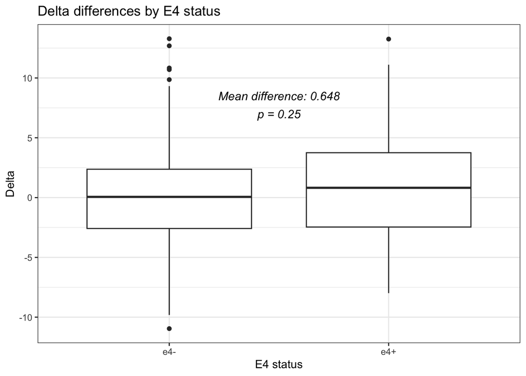

### Amyloid status

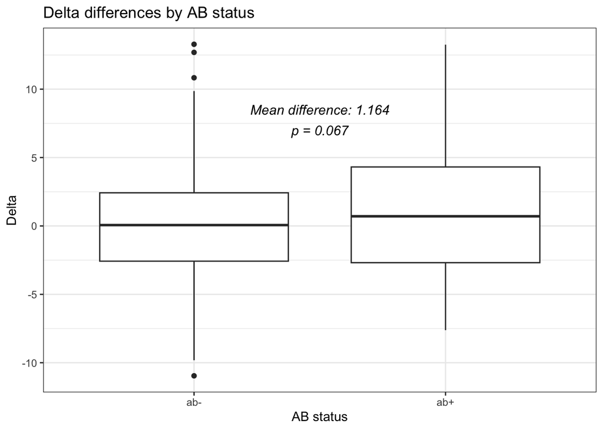

### Sex differences

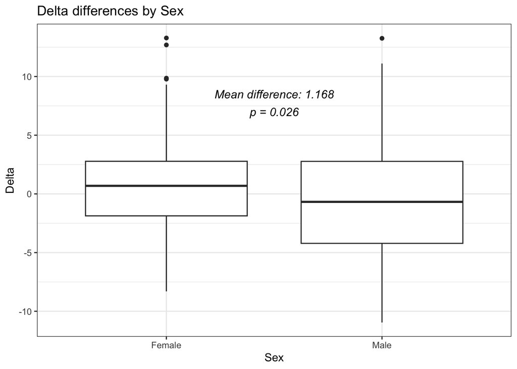

## Biomarkers

Correlation between BrainAge delt and different biomarkers. Sensitivity analysis includes addin sex, educaiton, APOEe4, AB-status and MRI Age as covariates. Further sensitivity analysis limits datapoints to those within 1 year of the MRI.

### PACC

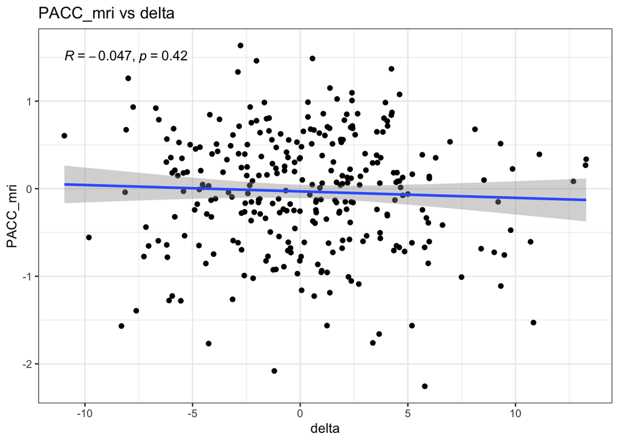

```
## Sensitivity analysis:
```

```
## Correlation with delta including covariates: -0.08347256 0.1555244
```

```
## Correlation with delta including covariates and time difference: -0.1058491 0.08975296
```

### AB

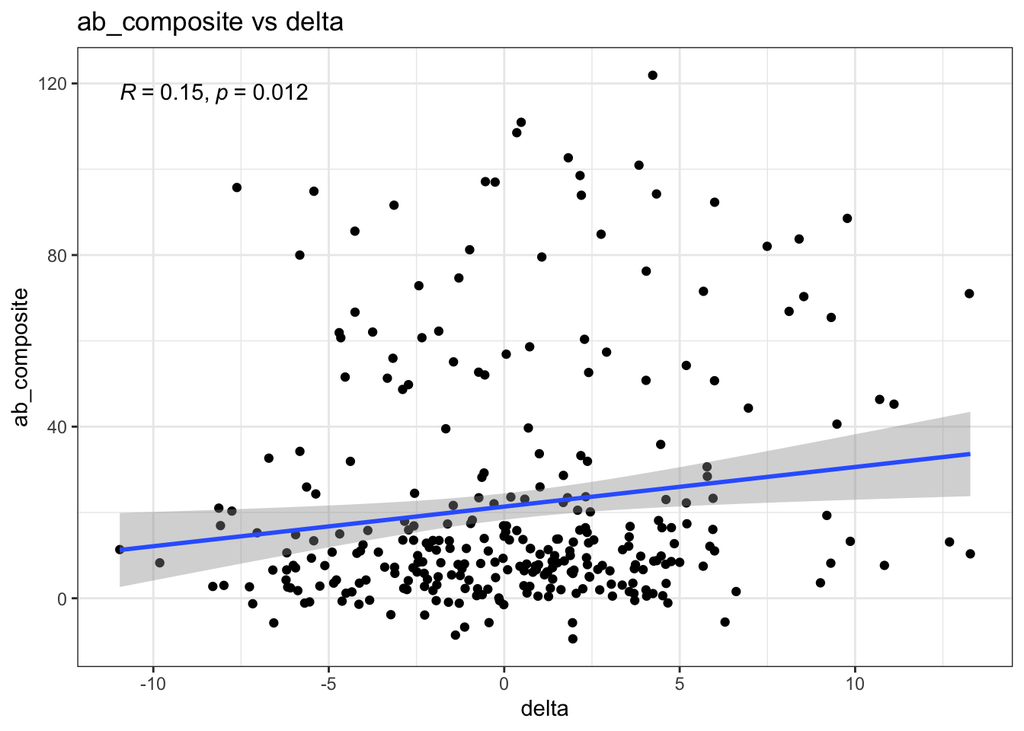

```
## Sensitivity analysis:
```

```
## Correlation with delta including covariates: 0.08023486 0.1722484
```

```
## Correlation with delta including covariates and time difference: 0.09757832 0.1019977
```

### ptau217

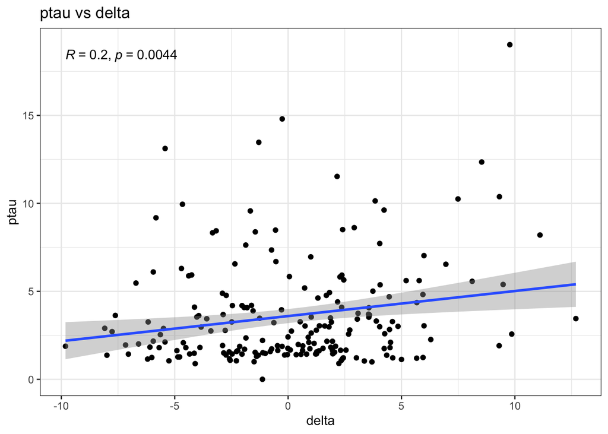

```
## Sensitivity analysis:
```

```
## Correlation with delta including covariates: 0.1889458 0.008159636
```

```
## Correlation with delta including covariates and time difference: 0.1997575 0.006125103
```

### TAU

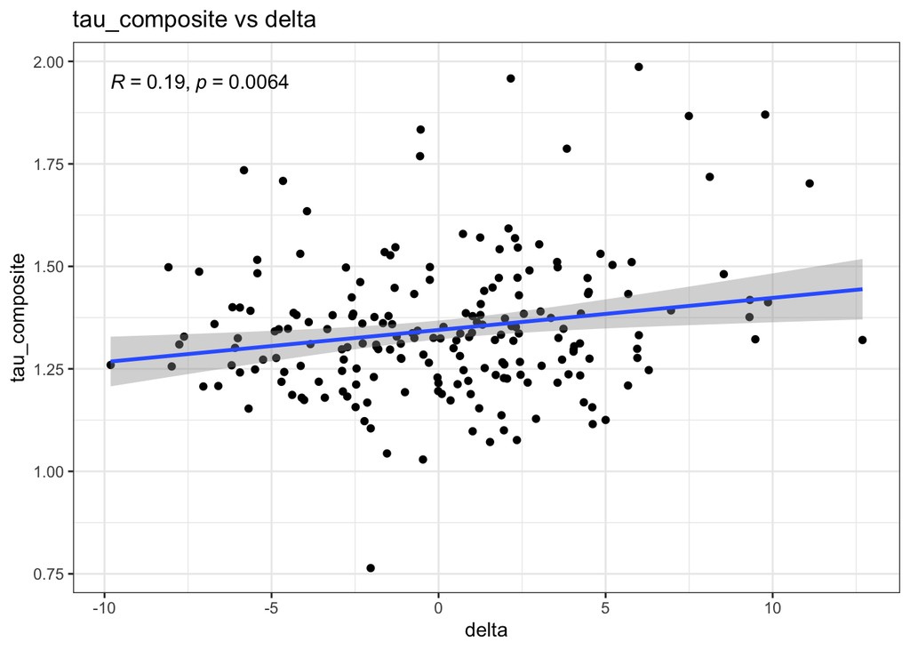

```
## Sensitivity analysis:
```

```
## Correlation with delta including covariates: 0.172365 0.01597296
```

```
## Correlation with delta including covariates and time difference: 0.07228337 0.5671805
```

# ADNI CU

Command used: model_age -o analysis/final/adni -f data/final/adni/processed/structural_features.csv –clinical data/final/adni/processed/clinical.csv

```
## Cognitively Unimpaired
```

```
## Delta mean: -0.2228206
```

```
## Delta std: 3.376072
```

## Delta differences

### E4 status

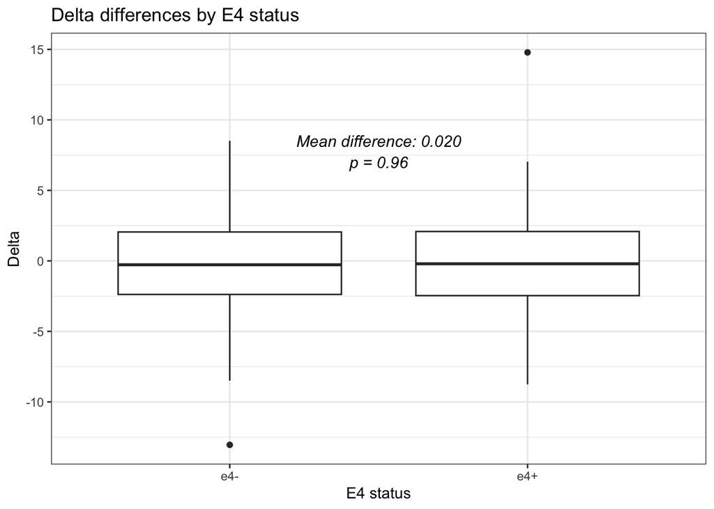

### Amyloid status

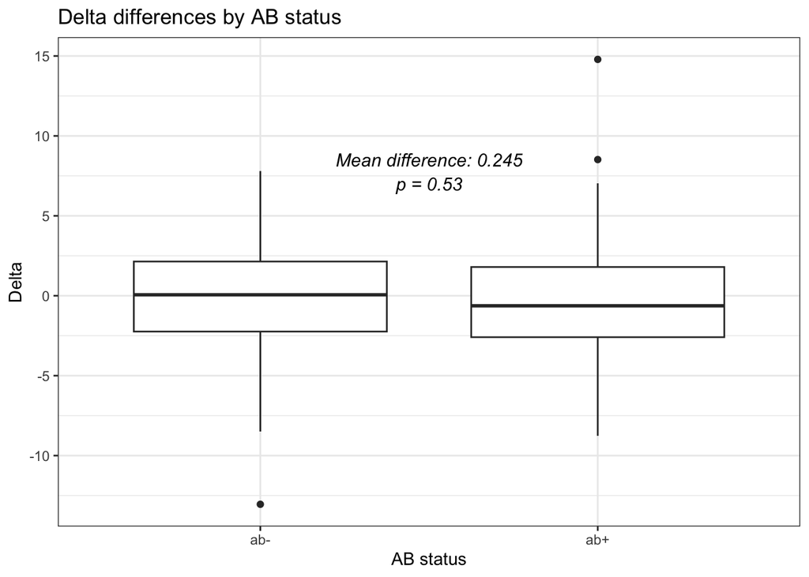

### Sex differences

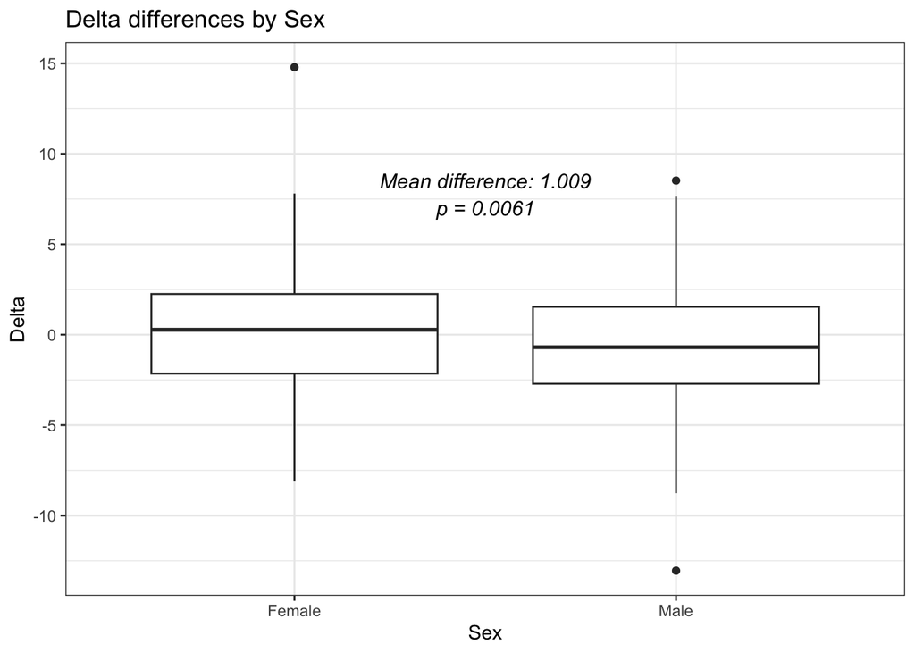

## Biomarkers

Correlation between BrainAge delt and different biomarkers. Sensitivity analysis includes addin sex, educaiton, APOEe4, AB-status and MRI Age as covariates. Further sensitivity analysis limits datapoints to those within 1 year of the MRI.

### PACC

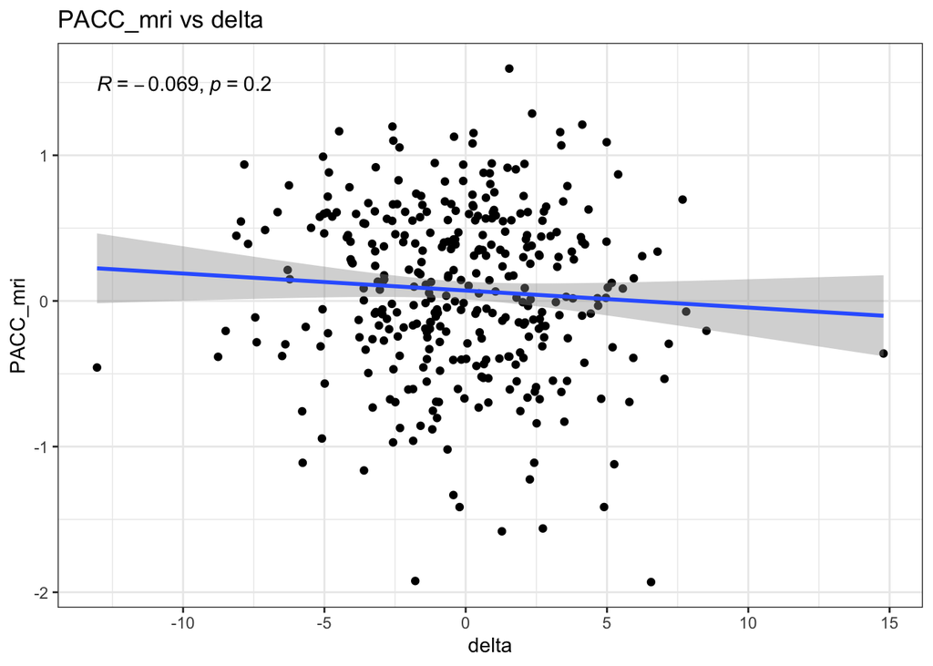

```
## Sensitivity analysis:
```

```
## Correlation with delta including covariates: -0.1394401 0.01015663
```

```
## Correlation with delta including covariates and time difference: -0.1394401 0.01015663
```

### AB

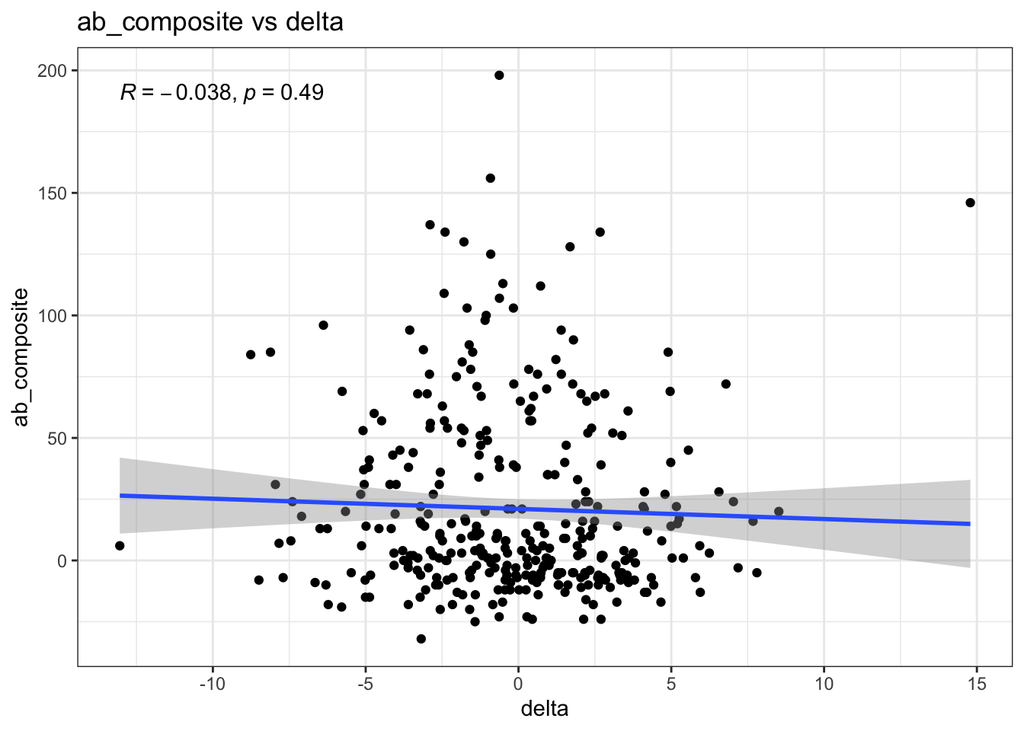

```
## Sensitivity analysis:
```

```
## Correlation with delta including covariates: -0.02599843 0.6333661
```

```
## Correlation with delta including covariates and time difference: -0.07155647 0.2448108
```

### ptau217

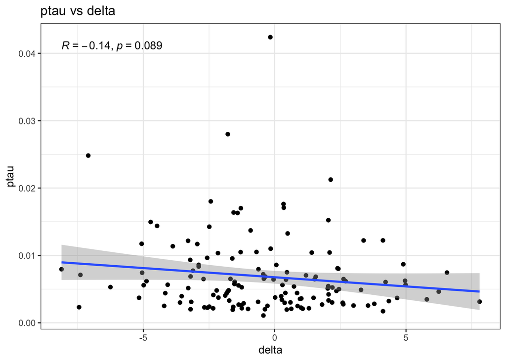

```
## Sensitivity analysis:
```

```
## Correlation with delta including covariates: -0.08520068 0.3276737
```

```
## Correlation with delta including covariates and time difference: 0.02875397 0.8244328
```

### TAU

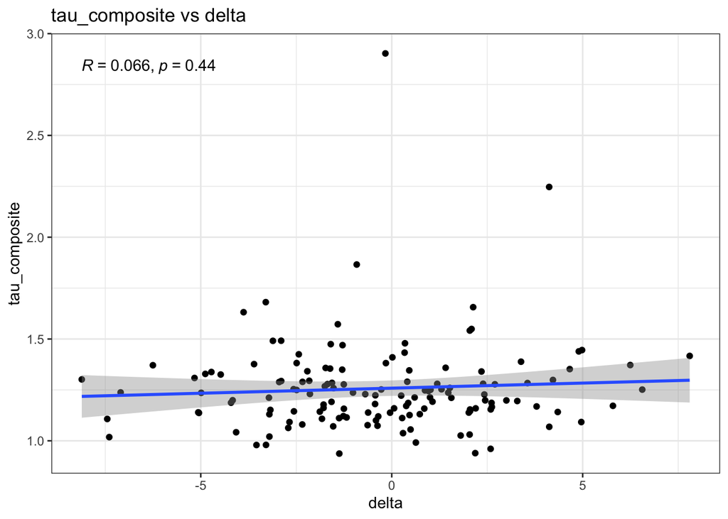

```
## Sensitivity analysis:
```

```
## Correlation with delta including covariates: 0.1123826 0.1960685
```

```
## Correlation with delta including covariates and time difference: 0.04844289 0.671598
```

# ADNI MCI

```
## Mild Cognitive Impairment
```

```
## Delta mean: 1.63186
```

```
## Delta std: 3.782902
```

## Delta differences

### E4 status

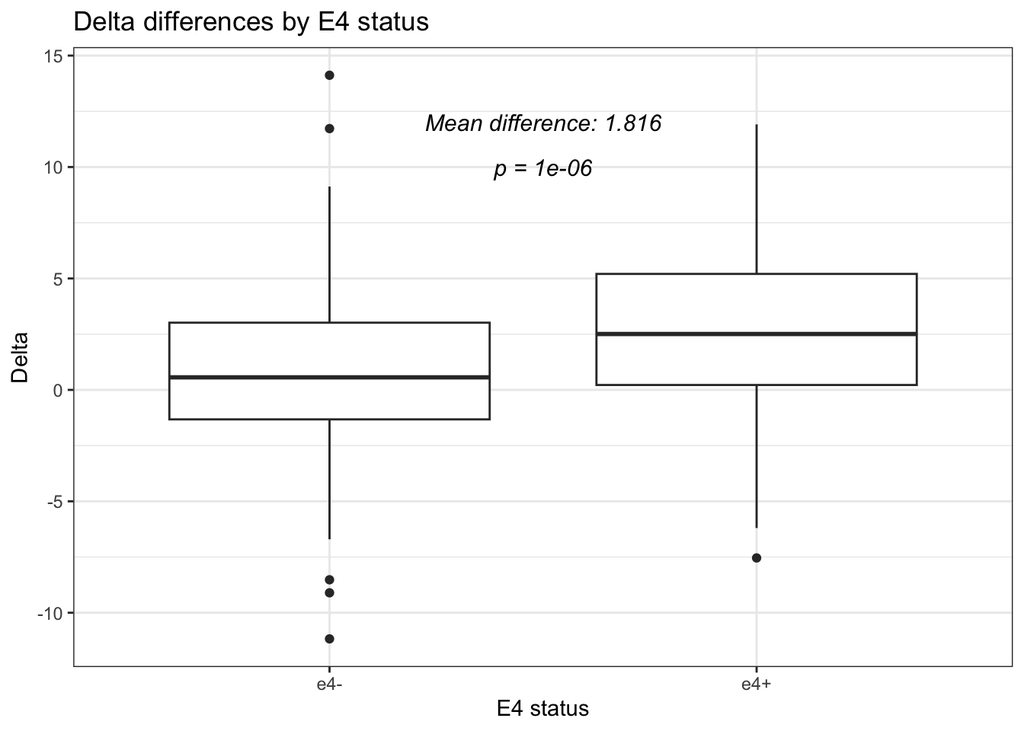

### Amyloid status

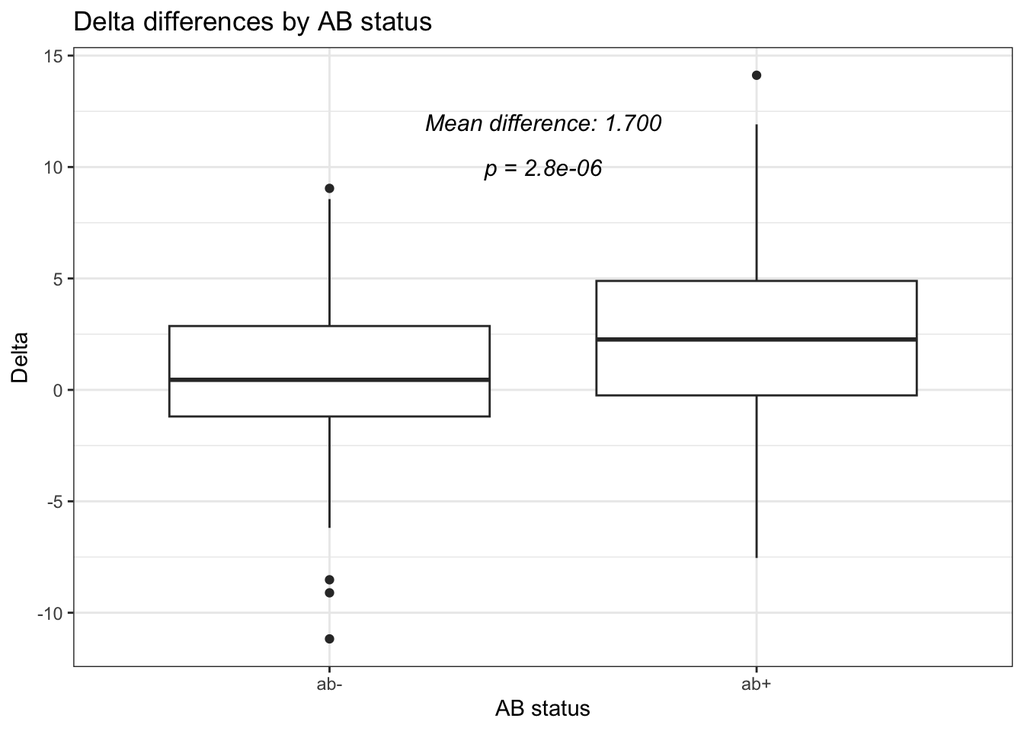

### Sex differences

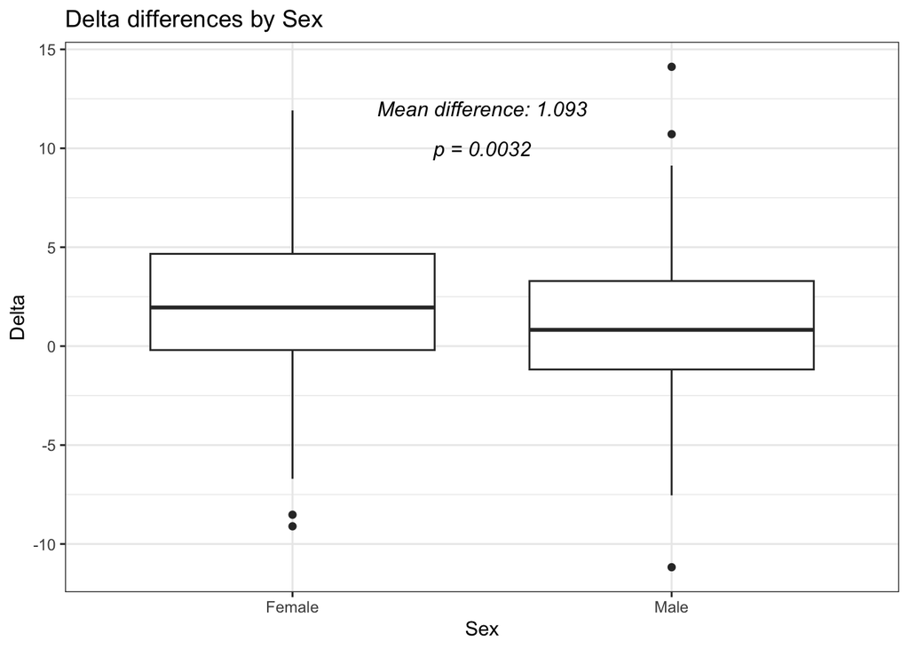

### MCI vs CU

```
## Beta coefficient: 0.5409084
```

```
## Standard error: 0.08168485
```

```
## p-value: 3.54624e-11
```

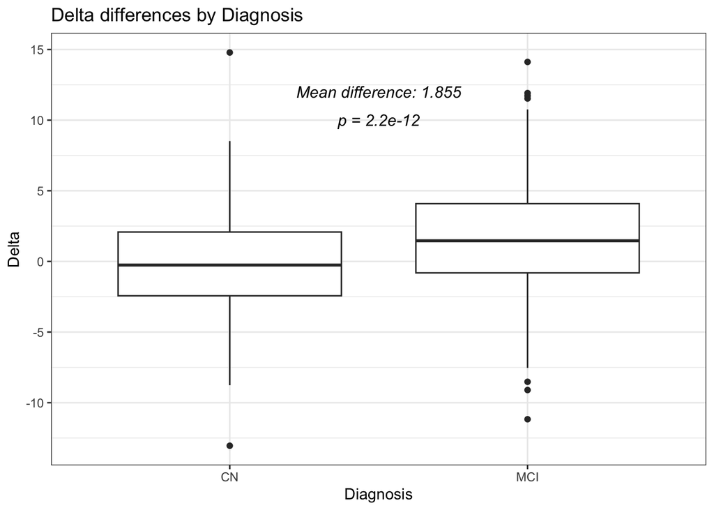

## Biomarkers

Correlation between BrainAge delt and different biomarkers. Sensitivity analysis includes addin sex, educaiton, APOEe4, AB-status and MRI Age as covariates. Further sensitivity analysis limits datapoints to those within 1 year of the MRI.

### PACC

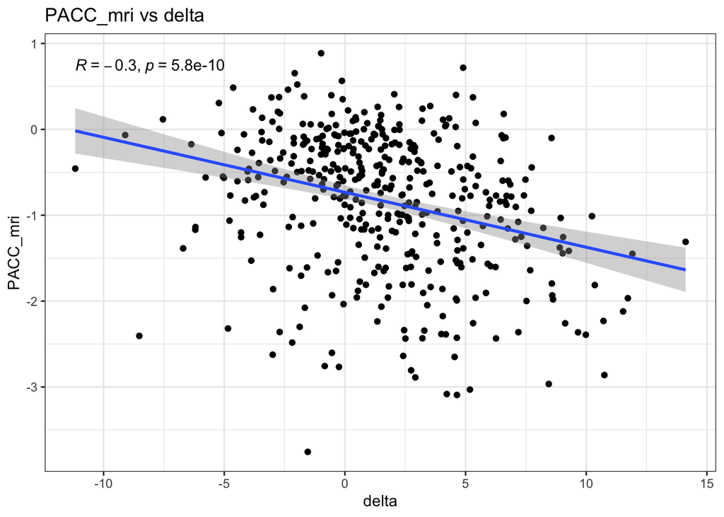

```
## Sensitivity analysis:
```

```
## Correlation with delta including covariates: -0.337818 2.109469e-12
```

```
## Correlation with delta including covariates and time difference: -0.337818 2.109469e-12
```

### AB

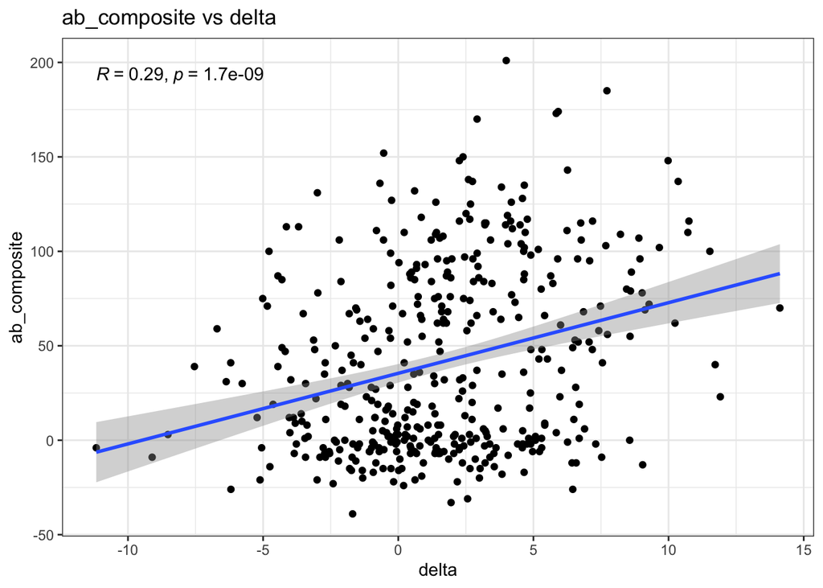

```
## Sensitivity analysis:
```

```
## Correlation with delta including covariates: 0.2091212 1.965774e-05
```

```
## Correlation with delta including covariates and time difference: 0.2267829 2.427922e-05
```

### ptau217

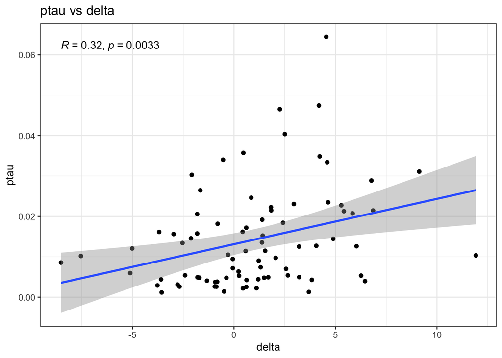

```
## Sensitivity analysis:
```

```
## Correlation with delta including covariates: 0.1435163 0.2161521
```

```
## Correlation with delta including covariates and time difference: -0.006040086 0.9742743
```

### TAU

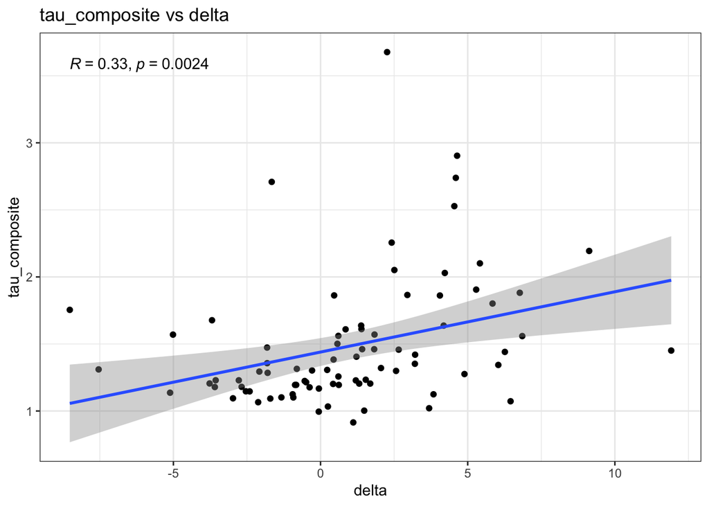

```
## Sensitivity analysis:
```

```
## Correlation with delta including covariates: 0.2152751 0.06182025
```

```
## Correlation with delta including covariates and time difference: 0.1070154 0.4642449
```

# Meta-analysis

## E4 status

```
## E4 All: 0.214262 ( 0.1225524 )
```

```
## E4 CU: 0.07981631 ( 0.4670774 )
```

## AB status

```
## AB status All: 0.1647993 ( 0.2730926 )
```

```
## AB status CU: 0.08726586 ( 0.7060836 )
```

## Sex

```
## Sex All: 0.2125713 ( 0.03616068 )
```

```
## Sex CU: 0.3098594 ( 0.06123631 )
```

## PACC

```
## PACC All: -0.05269348 ( 0.4994625 )
```

```
## PACC CU: -0.03864339 ( 0.09065239 )
```

## AB

```
## AB All: 0.1265149 ( 0.16919 )
```

```
## AB CU: 0.04986527 ( 0.6748085 )
```

## pTau217

```
## pTau217 All: 0.1632234 ( 0.1537741 )
```

```
## pTau217 CU: 0.05712561 ( 0.7532778 )
```

## Tau

```
## Tau All: 0.2453438 ( 0.06916416 )
```

```
## Tau CU: 0.1008083 ( 0.4161549 )
```

## CU results

```
##    labels   estimates    ci_lower   ci_upper      pvals       i2        tau2
## 1 APOEe4+  0.07981631 -0.83452516 0.99415777 0.46707744  0.00000 0.000000000
## 2  Female  0.30985944 -0.07002528 0.68974416 0.06123631  0.00000 0.000000000
## 3    PACC -0.03864339 -0.10903801 0.03175124 0.09065239  0.00000 0.000000000
## 4  Aβ-PET  0.04986527 -1.08070800 1.18043853 0.67480850 63.98466 0.005065728
## 5 pTau217  0.05712561 -1.72107116 1.83532237 0.75327778 81.90014 0.016040537
## 6 Tau-PET  0.10080830 -0.88041884 1.08203544 0.41615488 36.66910 0.002187442
```

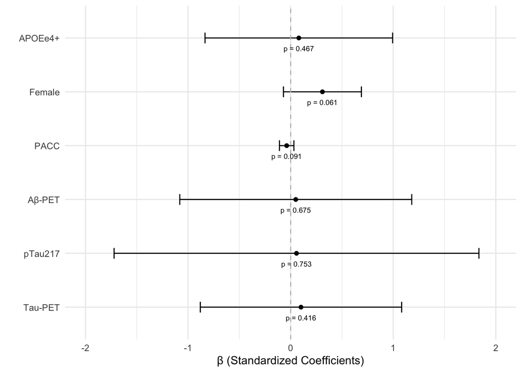

## MCI results

```
##    labels  estimates    ci_lower   ci_upper        pvals
## 1 APOEe4+  0.5016849  0.29321053  0.7101593 2.397502e-06
## 2  Female  0.2907537  0.09473482  0.4867727 3.646138e-03
## 3    PACC -0.2379878 -0.31149208 -0.1644835 5.807488e-10
## 4  Aβ-PET  0.3085322  0.21035130  0.4067131 1.731692e-09
## 5 pTau217  0.2884503  0.10202679  0.4748739 3.266955e-03
## 6 Tau-PET  0.3508594  0.13109755  0.5706212 2.445951e-03
```

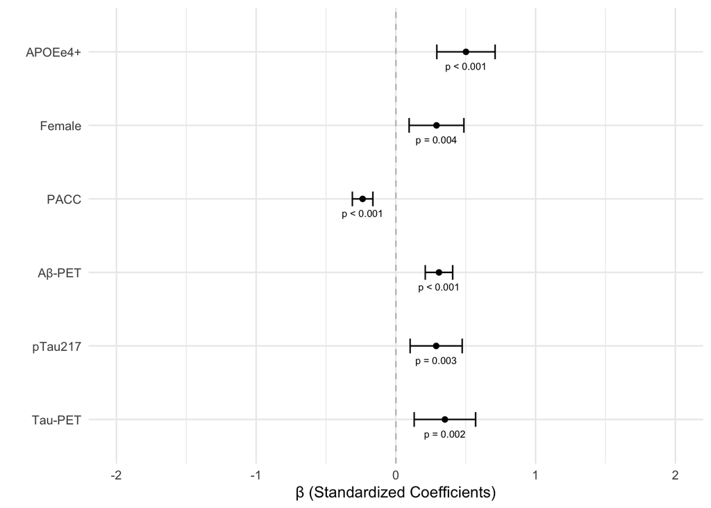